# TalkingData - Detecção de Fraudes no Tráfego de Cliques em Propagandas de Aplicações Mobile

Victor Saraiva Rocha

14/03/2021

#### **Projeto de conclusão de curso -> Data Science Academy - Big Data Analytics com R e Microsoft Azure Machine Learning.**

## **1.Descrição do projeto.**

À esse projeto será utilizado o dataset disponibilizado na competição [TalkingData AdTracking Fraud Detection Challenge](https://www.kaggle.com/c/talkingdata-adtracking-fraud-detection/data), através do site [Kaggle](https://www.kaggle.com/).

O risco de fraude está em toda parte, mas para as empresas que anunciam online, a fraude de cliques pode acontecer em um volume avassalador, resultando em dados de cliques enganosos e dinheiro desperdiçado. Os canais de anúncios podem aumentar os custos simplesmente quando pessoas ou bots clicam nos anúncios em grande escala, o que na prática não gera o resultado esperado. Com mais de 1 bilhão de dispositivos móveis em uso todos os meses, a China é o maior mercado móvel do mundo e, portanto, sofre com grandes volumes de tráfego fraudulento.

A [TalkingData](https://www.talkingdata.com), a maior plataforma de Big Data independente da China, cobre mais de 70% dos dispositivos móveis ativos em todo o país. Eles lidam com 3 bilhões de cliques por dia, dos quais 90% são potencialmente fraudulentos. Sua abordagem atual para impedir fraudes de cliques para desenvolvedores de aplicativos é medir a jornada do clique de um usuário em todo o portfólio e sinalizar endereços IP que produzem muitos cliques, mas nunca acabam instalando aplicativos. Com essas informações, eles criaram uma lista negra de IPs e uma lista negra de dispositivos.

### **1.1 Objetivo.**

o Objetivo desse projeto será criarmos um algoritmo de machine learning que faça predições se um usuário **baixará** ou **não baixará** um aplicativo após ter clicado num anúncio.

Ao projeto será considerado um bom modelo caso a taxa de **acurácia** chegue à **90%**.

## **2. Coletando os dados.**

Para conseguirmos carregar os dados ao R, realizar as análises e criar o algoritmo de machine learning para realizar as predições, preciremos carregar as bibliotecas necessárias ao projeto.

```r
# Carregando as bibliotecas.
library(data.table)
library(dplyr)
library(lubridate)
library(ggplot2)
library(stringr)
library(bigreadr)
library(pryr)
library(fasttime)
library(ROSE)
library(caret)
library(randomForest)
library(rpart)
```

Como trabhalharemos com um arquivo bem grande teremos que aumentar o limite de memória utilizada pelo R para processamento Além disso, removeremos a notação científica.

```r
# Removendo a notação científica.
options(scipen = 1000000)

# Aumentando o limite de memória de processamento.
memory.limit(99999999999)
```

Para a análise exploratória dos dados trabalharemos com uma amostra de 25% do total de linhas do dataset, pois o arquivo possui mais de 7GB e meu computador não tem memória suficiente para processar arquivos deste tamaho.

Para tanto, será necessário sabermos o número total de linhas do conjunto de dados. O pacote **bigreadr** nos auxiliará com a manipulação de arquivos muito grande. Para a contagem das linhas o pacote nos oferece a função “nlines” o qual consegue realizar a contagem das linhas sem a necessidade de carregamento dos dados.

```r
# Lendo o total de linhas do arquivo de treino.
tot_linhas <- nlines("train.csv")

# Visualizando o total de linhas.
tot_linhas
```

```
## [1] 184903891
```

Como vimos o conjunto de dados possui um total de 184.903.891 linhas.

Conforme falado dividiremos esse total de linhas por 4 para iniciarmos nossa análise exploratória.

```r
# Divindo o total de linhas por 4.
linhas_conj <- round(tot_linhas / 4)

# Visualizando a quantidade de linhas de cada arquivo.
linhas_conj
```

```
## [1] 46225973
```

Cada arquivo terá um total de 46.225.973 linhas. Para que nossa amostra possa representar o mais fielmente o conjunto de dados precisaremos retirar linhas de cada um dos 4 conjuntos de dados que serão criados.

```r
# Dividindo os dados em 4 conjuntos.
split_file('train.csv', every_nlines = linhas_conj, prefix_out = 'train', repeat_header = T)
```

#### **Criando a amostra.**

```r
# Confirmando a criação dos arquivos de treino
dir(pattern = '.txt')
```

```
## [1] "train_1.txt" "train_2.txt" "train_3.txt" "train_4.txt"
```

```r
# Criando uima variável com o nome dos arquivos
conjuntos <- c()

for (i in 1:length(dir(pattern = '.txt'))){
  conjuntos[i] <- paste('train_',i,'.txt', sep = "")
}

# Validando a variável criada
conjuntos
```

```
## [1] "train_1.txt" "train_2.txt" "train_3.txt" "train_4.txt"
```

```r
# Criando uma função para leitura das linhas de cada conjunto criado.
ler_arq <- function(dados){
  tabela <- data.table()
  for (i in dados){
   treino <- fread(i)
   tabela <- rbind(tabela, treino[sample(1:nrow(treino),46225973/4),], use.names=F)
  }
  return(tabela)
}

# Lendo as linhas de cada arquivo criado.
train_data <- ler_arq(conjuntos)
```

```r
# Verificando a quantidade de linhas do arquivo
nrow(train_data)
```

```
## [1] 46225972
```

#### **Dicionário dos dados:**

| **Variáveis** | **Significado** |
| --- | --- |
| **ip** | Endereço de ip do click |
| **app** | Aplicativo de marketing utilizado |
| **device** | Modelo do aparelho telefônico - ex( iphone 6 plus, iphone 7, huawei mate 7, etc) |
| **os** | Sistema operacional do aparelho telefônico |
| **channel** | ID do canal do editor de anúncios para celular |
| **click_time** | Data e hora do click |
| **attributed_time** | Data e hora do download do aplicativo - caso o usuário tenha baixado após ter clicado num anúncio |
| **is_attributed** | Variável target (alvo), é o que usaremos para realizar as predições de ML - Indica se o aplicativo foi baixado |

Vamos salvar nossa amostra num arquivo **csv** para evitarmos de termos que refazer todo o processo.

```r
# Salvando a amostra num arquivo csv.
fwrite(train_data, 'train_sample.csv')
```

```r
# Vamos verificar o tamanho da amostra
object_size(train_data)
```

```
## 1.87 GB
```

Pudemos ver que o arquivo foi carregado com 1,87GB.

```r
# Realizando a leitura das colunas do dataset.
conames <- colnames(train_data)

# Verificando os nomes.
conames
```

```
## [1] "ip"              "app"             "device"          "os"
## [5] "channel"         "click_time"      "attributed_time" "is_attributed"
```

## **3. Análise Exploratória dos Dados.**

Vamos iniciar a análise exploratória dos dados.

Primeiramente, vamos averiguar se existem linhas **duplicadas** ou linhas com valores **NA** em nosso conjunto de dados.

```r
# Criando uma função para validar a existência  de valores duplicados ou NA's
na_dupli <- function(dados){

  # Validando a existÊncia de valores duplicados
  if (anyDuplicated(dados)){
    dupli <- length(which(duplicated(dados)))

    # Validando se existe algum valor NA
    if (!anyNA(dados)){
      nas <- 0

    }else{
      nas <- length(which(is.na(dados)))
    }
  }else{
    dupli <- 0

    if (!anyNA(dados)){
      nas <- 0

    }else{
      nas <- length(which(is.na(dados)))
    }
  }

  # Criando um data frame para tabelar as informações.
  df <- data.frame()
  df[1,'Tot_linhas'] <- nrow(dados)
  df[1,'Tot_linhas_Duplicada'] <- dupli
  df[1,'Percent_Duplicadas'] <- round((dupli / nrow(dados)*100), digits = 2)
  df[1,'NA_values'] <- nas
  return(df)
}

# Computando os resultados na variável infos
infos <- na_dupli(train_data)

# Transformando os dados em um dataframe para melhor visualização dos dados
resume <- round(data.frame(t(infos)), digits = 2)

# Renomeando a coluna
names(resume) <- 'train1'

# Visualizando
format(resume, big.mark='.', decimal.mark=',')
```

```
##                             train1
## Tot_linhas           46.225.972,00
## Tot_linhas_Duplicada    236.337,00
## Percent_Duplicadas            0,51
## NA_values                     0,00
```

Vamos gravar as informações num arquivo csv para histórico da análise.

```r
# Copiando os indices à uma coluna dentro do dataframe
resume['Resume'] <- rownames(as.data.frame(t(infos)))

# Salvando as informações adquiridas num arquivo .csv
fwrite(resume, 'na_dupli_table.csv')
```

Como pudemos verificar na tabela acima os conjuntos de dados não possuem valores **NA** e o total de linhas **duplicadas 236.337** equivalem à apenas **0,51%** dos dados. Dessa forma, optaremos por excluir as linhas duplicadas dos dados.

```r
# Retirando os valores duplicados
train_data <- train_data[!duplicated(train_data),]

# Validando a remoção dos valores duplicados
cat('Linhas duplicadas: ',length(which(duplicated(train_data))), sep = '')
```

```
## Linhas duplicadas: 0
```

```r
# Verificando o total de linhas
cat('Total de linhas: ', format(nrow(train_data), big.mark='.', decimal.mark=','), sep = '')
```

```
## Total de linhas: 45.989.635
```

```r
# Visualizando as 5 primeiras linhas dos dados.
head(train_data, 5)
```

```
##        ip app device os channel          click_time attributed_time
## 1: 144286   3      1 19     280 2017-11-07 02:28:04
## 2:  94729  14      1  3     446 2017-11-06 23:56:03
## 3:  15530   8      1 19     145 2017-11-07 04:32:59
## 4:  54991   3      1 19     130 2017-11-06 23:54:50
## 5:  43715   2      1 19     122 2017-11-07 07:05:54
##    is_attributed
## 1:             0
## 2:             0
## 3:             0
## 4:             0
## 5:             0
```

Conforme tabela acima, a coluna **attributed_time**, que se refere à data e hora do download do aplicativo - caso o usuário tenha baixado após ter clicado num anúncio - possui algumas linhas com campos em branco, ou seja, houve clique no anúncio, porém não houve download do aplicativo. Dessa forma, analisaremos em cada coluna (variável) quantos valores em brancos possuem.

```r
# Criando um dataframe e preenchendo com as informações
df <- data.frame(train_blanks = seq(conames), row.names = conames)
for (i in seq(conames)){
  df[i,'train_blanks'] <- length(which(train_data[[conames[i]]]==''))
}

# Visualizando a informação.
format(df, big.mark='.', decimal.mark=',')
```

```
##                 train_blanks
## ip                         0
## app                        0
## device                     0
## os                         0
## channel                    0
## click_time                 0
## attributed_time   45.875.534
## is_attributed              0
```

Podemos notar que existem 45.875.534 valores em branco na variável attributed_time.

```r
# Veriricando quanto elas equivalem do total.
cat(round(df[7,1] / nrow(train_data), digits = 5),'%', sep = '')
```

```
## 0.99752%
```

```r
# Vamos verificar quantos downloads foram realizados
cat(format((nrow(train_data) - df[7,1]), big.mark='.', decimal.mark=','), 'downloads')
```

```
## 114.101 downloads
```

Com isso podemos concluir quase nenhum dos cliques realizados nos anúncios levam a downloads.

Vamos verificar quais as classes que o R considerou no momento que carregou os dados.

```r
# Verificando dados
str(train_data)
```

```
## Classes 'data.table' and 'data.frame':   45989635 obs. of  8 variables:
##  $ ip             : int  144286 94729 15530 54991 43715 16775 32717 78478 50087 95388 ...
##  $ app            : int  3 14 8 3 2 15 15 2 11 2 ...
##  $ device         : int  1 1 1 1 1 1 1 1 1 1 ...
##  $ os             : int  19 3 19 19 19 19 1 10 41 19 ...
##  $ channel        : int  280 446 145 130 122 245 315 477 319 212 ...
##  $ click_time     : chr  "2017-11-07 02:28:04" "2017-11-06 23:56:03" "2017-11-07 04:32:59" "2017-11-06 23:54:50" ...
##  $ attributed_time: chr  "" "" "" "" ...
##  $ is_attributed  : int  0 0 0 0 0 0 0 0 0 0 ...
##  - attr(*, ".internal.selfref")=<externalptr>
```

Conforme mostra a tabela acima, as variáveis carregadas como **int** (inteiro) se referem na verdade à variáveis categóricas e as variáveis carregadas como **char** (caracter) na verdade se tratam de variáveis de séries temporais. Com isso, faremos a conversão delas para factor e datatempo, respectivamente.

Para podermos transformar a variável **attributed_time** em uma variável de data, precisaremos preencher as linhas vazias por **NA**.

```r
# Substituindo os valores vazios por NA
train_data$attributed_time[train_data$attributed_time==''] <- NA

# Validando se os valores NA's foram atualizados no dataset
length(which(is.na(train_data$attributed_time)))
```

```
## [1] 45875534
```

Pudemos confirmar que os valores em branco foram atualizados com os valores NA. Para definitivamente convertemos as variáveis, vamos criar uma função.

```r
# Função para as conversões.
conversao <- function(coluna){
  if (class(train_data[[coluna]])=='integer'){
    train_data[[coluna]] <- as.factor(train_data[[coluna]])
  } else {
    train_data[[coluna]] <- fastPOSIXct(train_data[[coluna]])
  }
  return(train_data)
}

# Realizando as conversões.
for(i in conames){
    train_data <- conversao(i)
}

# Validando as conversões
str(train_data)
```

```
## Classes 'data.table' and 'data.frame':   45989635 obs. of  8 variables:
##  $ ip             : Factor w/ 216302 levels "1","5","6","9",..: 52362 28851 4709 16829 13274 5089 9917 23959 15333 29043 ...
##  $ app            : Factor w/ 563 levels "0","1","2","3",..: 4 15 9 4 3 16 16 3 12 3 ...
##  $ device         : Factor w/ 2315 levels "0","1","2","4",..: 2 2 2 2 2 2 2 2 2 2 ...
##  $ os             : Factor w/ 513 levels "0","1","2","3",..: 20 4 20 20 20 20 2 11 41 20 ...
##  $ channel        : Factor w/ 192 levels "0","3","4","5",..: 98 157 43 37 29 82 102 178 104 62 ...
##  $ click_time     : POSIXct, format: "2017-11-07 00:28:04" "2017-11-06 21:56:03" ...
##  $ attributed_time: POSIXct, format: NA NA ...
##  $ is_attributed  : Factor w/ 2 levels "0","1": 1 1 1 1 1 1 1 1 1 1 ...
##  - attr(*, ".internal.selfref")=<externalptr>
```

Pudemos constatar que as conversões foram realizadas com sucesso.

Agora, vamos verificar quantos valores únicos cada uma das variáveis possuem, retiraremos as colunas **click_time, attributed_time, is_attributed**.

```r
# Verificando os valores únicos das variáveis.
unicos <- data.frame(v_unicos = sapply(train_data[,-c('click_time', 'attributed_time', 'is_attributed')], function(cols){

  length(unique(cols))

}))

# Visualizando a informação
unicos
```

```
##         v_unicos
## ip        216302
## app          563
## device      2315
## os           513
## channel      192
```

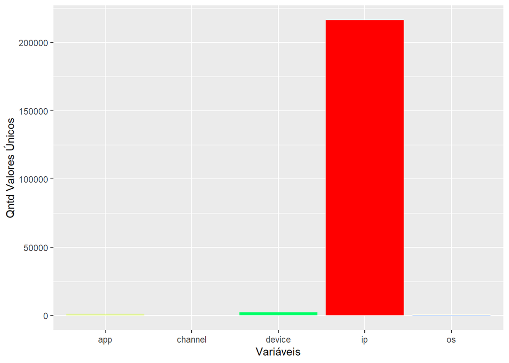

```r
# vamos visualizar a informação acima através de um gráfico
unicos %>% ggplot(aes(x=rownames(unicos), y=v_unicos)) + geom_bar(stat='identity', fill=rainbow(nrow(unicos))) +
  xlab('Variáveis') +
  ylab('Qntd Valores Únicos')
```

Dessa forma podemos constatar:

- 216302 números de IP
- 563 aplicativos de marketing
- 2315 modelos de aparelhos
- 513 sistemas operacionais
- 192 canais de anúncio

Vamos analisar em cada variável quantos valores duplicados elas possuem.

```r
# Criando um dataframe para verificarmos os valores duplicados.
val_dupli <- data.frame(train = sapply(train_data[,-c(6,7,8)], function(cols){

  length(which(duplicated(cols)))

}))

# Visualizando.
format(val_dupli, big.mark='.', decimal.mark=',')
```

```
##              train
## ip      45.773.333
## app     45.989.072
## device  45.987.320
## os      45.989.122
## channel 45.989.443
```

Vamos ver o percentual que esses valores representam.

```r
# criando um dataframe para computar as informações
df1 <- data.frame(train = seq(rownames(val_dupli)))

# Preenhendo as informações no dataframe
for (i in seq(nrow(val_dupli))){
     df1[i,1] <- round(val_dupli[i,1]*100/nrow(train_data), digits = 5)
     if (i==5){
       rownames(df1) <- rownames(val_dupli)
       print(df1)
       rm(df1)
       rm(i)
     }
}
```

```
##            train
## ip      99.52967
## app     99.99878
## device  99.99497
## os      99.99888
## channel 99.99958
```

Vamos verificar se difereneça entre os valores duplicados e as linhas totais do dataset se igualam aos valores únicos.

```r
# Criando um dataframe para cmomputador as informações.
df1 <- data.frame(train = seq(rownames(val_dupli)))

# Preenhendo as informações no dataframe.
for (i in seq(nrow(val_dupli))){
  df1[i,1] <- nrow(train_data)-val_dupli[i,1]
  if (i==5){
    rownames(df1) <- rownames(val_dupli)
    print(df1)
    rm(df1)
    rm(i)
  }
}
```

```
##          train
## ip      216302
## app        563
## device    2315
## os         513
## channel    192
```

Conforme vimos, a maior parte dos dados são de dados duplicados. A única variável que possui uma quantidade um pouco mais diversificada é a variável ip. O que faz sentido, pois existem muito mais usuários do que serviços disponíveis. Além disso constatamos que a diferença entra os duplicados e as linhas totais se igualaram aos valores únicos.

Vamos verificar os 5 primeiros registros com mais cliques dentro do dataset.

```r
# Criando uim dataframe com as informações.
primeiros_5 <-data.frame(lapply(train_data[,-c(6,7,8)], function(cols){

  head(sort(table(cols, dnn='var'),  decreasing = T), 5)


}))

# Visualizando as informações.
format(primeiros_5, big.mark='.', decimal.mark=',')
```

```
##   ip.var ip.Freq app.var  app.Freq device.var device.Freq os.var    os.Freq
## 1   5348 307.565       3 8.419.515          1  43.359.830     19 10.991.743
## 2   5314 291.096      12 5.997.746          2   2.015.149     13  9.887.142
## 3  73516 191.607       2 5.399.405          0     257.017     17  2.395.288
## 4  73487 190.328       9 4.103.744       3032     172.619     18  2.230.186
## 5  53454 123.553      15 3.982.990       3543      66.946     22  1.845.042
##   channel.var channel.Freq
## 1         280    3.717.107
## 2         245    2.211.706
## 3         107    2.104.810
## 4         477    1.792.255
## 5         134    1.473.865
```

```r
# Gravando as informações num arquivo .csv
fwrite(primeiros_5, '5_primeiros.csv')
```

Vamos visualizar as informações da tabela cima através de um gráfico de barras.

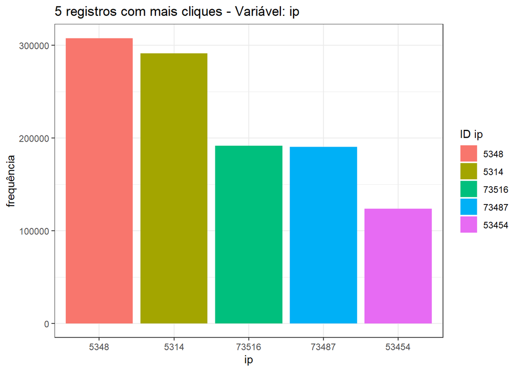

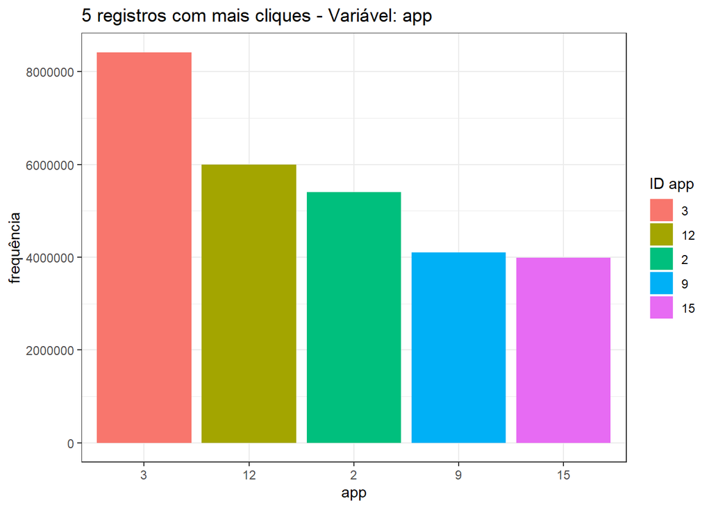

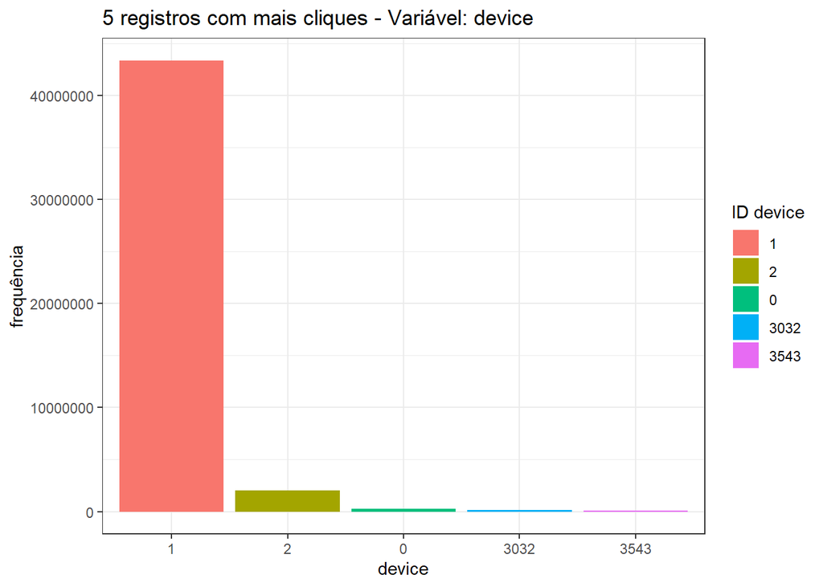

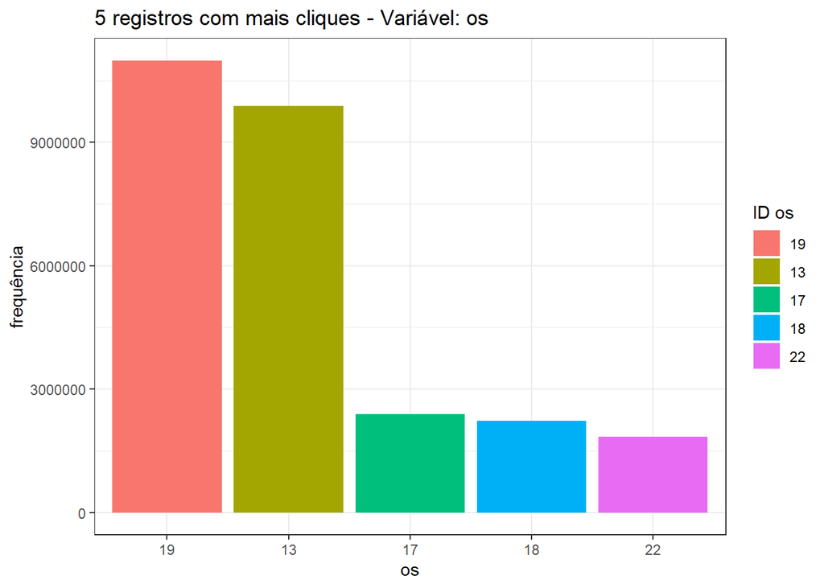

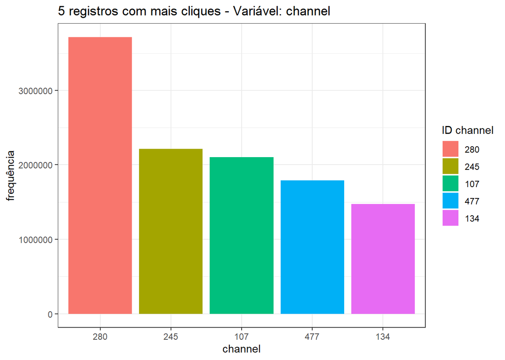

```r
# Criando vetores para os índices do dataframe.
c_impar <- seq(1, 10, 2)
c_par <- seq(2, 10, 2)

# Criando uma função para criação do gráfico de barras.
bars <- function(impar, par){
  ggplot(primeiros_5, aes(x=primeiros_5[,impar], y=primeiros_5[,par], fill=primeiros_5[,impar])) +
  geom_bar(stat='identity') +
  xlab(str_extract(colnames(primeiros_5[impar]),'\\w+')) +
  ylab('frequência') +
  theme_bw() +
  labs(fill=paste('ID', str_extract(colnames(primeiros_5[impar]),'\\w+'))) +
  ggtitle(paste('5 registros com mais cliques - Variável:', str_extract(colnames(primeiros_5[impar]),'\\w+')))
}

# Criando os gráficos.
Map(bars, c_impar, c_par)
```

Conforme os gráficos de barras nos mostraram podemos concluir que:

- Os ID’s dos endereços de ip’s estão com uma distribuição razoável, contudo, existem dois deles que se sobressaíram: 5348 e 5314.
- Os aplicativos com mais cliques são: : 3, 12 e 2.
- Os modelos tiveram uma alta discrepância , o modelo 1 foi o modelo com mais cliques.
- Os sistemas operacionais dos aparelhos que tiveram mais cliques foram o 19 e 13.
- Os canais de publicidade tiveram uma distribuição razoável de cliques, contudo, o com maior quantidade de cliques foi o 280.

Vamos verificar se o fato de as observações acima terem uma quantidade maior de cliques significa que tiveram uma quantidade maior de downloads efetuados.

Vamos criar uma função para visuarlizarmos as observações que mais tiveram downloads realizados. Alterando a variável **ord** podemos ordenar da forma que desejarmos:

- **1 -> 5 que mais baixaram**
- **2 -> 5 que menos baixaram**

```r
# Criando uma função para visualizarmos
y_no <- function(colun=conames[1:5], ord=1, linhas=5){
  if (ord==1){
    lapply(colun, function(cols){
      train_data[,c(cols,'is_attributed'), with=F] %>% group_by(across(cols)) %>%
        summarise(baixou = sum(is_attributed==1),
                  n_baixou = sum(is_attributed==0),
                  baixou_percent = round(100*baixou/(baixou+n_baixou), digits = 3),
                  n_baixou_percent = round(100*n_baixou/(baixou+n_baixou), digits = 3),
                  total_cliques = baixou+n_baixou) %>%
        arrange(desc(baixou)) %>%
        head(linhas)
    })

  } else if (ord==2){
      lapply(colun, function(cols){
        train_data[,c(cols,'is_attributed'), with=F] %>% group_by(across(cols)) %>%
          summarise(baixou = sum(is_attributed==1),
                  n_baixou = sum(is_attributed==0),
                  baixou_percent = round(100*baixou/(baixou+n_baixou), digits = 3),
                  n_baixou_percent = round(100*n_baixou/(baixou+n_baixou), digits = 3),
                  total_cliques = baixou+n_baixou) %>%
          arrange(desc(n_baixou)) %>%
          head(linhas)
      })
    } else{
        cat('Variável "ord" necessita ser 1 ou 2.
            1: Ordernar pelos 5 que mais baixaram.
            2: Ordernar pelos 5 que menos baixaram')
      }

}
```

Em caráter de análise utilizarei apenas os 5 primeiros registros dos dados. Contudo, podem ser selecionadas quantos registros desejar alterando o parâmetro **linhas**.

```r
# Criando uma variável para visualizarmos as informações.
downloaded <- y_no()

# Visualizando as informações.
downloaded
```

```
## [[1]]
## # A tibble: 5 x 6
##   ip    baixou n_baixou baixou_percent n_baixou_percent total_cliques
##   <fct>  <int>    <int>          <dbl>            <dbl>         <int>
## 1 5348     612   306953          0.199             99.8        307565
## 2 5314     529   290567          0.182             99.8        291096
## 3 73487    287   190041          0.151             99.8        190328
## 4 73516    247   191360          0.129             99.9        191607
## 5 5147     107    49331          0.216             99.8         49438
##
## [[2]]
## # A tibble: 5 x 6
##   app   baixou n_baixou baixou_percent n_baixou_percent total_cliques
##   <fct>  <int>    <int>          <dbl>            <dbl>         <int>
## 1 19     33157   196466          14.4              85.6        229623
## 2 35     15870     6736          70.2              29.8         22606
## 3 29     10011   152826           6.15             93.9        162837
## 4 10      8642   162482           5.05             95.0        171124
## 5 5       6845    87147           7.28             92.7         93992
##
## [[3]]
## # A tibble: 5 x 6
##   device baixou n_baixou baixou_percent n_baixou_percent total_cliques
##   <fct>   <int>    <int>          <dbl>            <dbl>         <int>
## 1 1       76361 43283469          0.176             99.8      43359830
## 2 0       25582   231435          9.95              90.0        257017
## 3 6         735     2403         23.4               76.6          3138
## 4 40        661     2400         21.6               78.4          3061
## 5 2         576  2014573          0.029            100.        2015149
##
## [[4]]
## # A tibble: 5 x 6
##   os    baixou n_baixou baixou_percent n_baixou_percent total_cliques
##   <fct>  <int>    <int>          <dbl>            <dbl>         <int>
## 1 19     19905 10971838          0.181             99.8      10991743
## 2 13     15328  9871814          0.155             99.8       9887142
## 3 24     11784    81320         12.7               87.3         93104
## 4 0       9566    81069         10.6               89.4         90635
## 5 29      5003    20803         19.4               80.6         25806
##
## [[5]]
## # A tibble: 5 x 6
##   channel baixou n_baixou baixou_percent n_baixou_percent total_cliques
##   <fct>    <int>    <int>          <dbl>            <dbl>         <int>
## 1 213      33378   161456          17.1              82.9        194834
## 2 113      14030   104842          11.8              88.2        118872
## 3 21       10469    64941          13.9              86.1         75410
## 4 101       8295   524740           1.56             98.4        533035
## 5 274       6437     3179          66.9              33.1          9616
```

Vamos criar um gráfico de barras para melhor visualizarmos as informações.

```r
# Criando uma função para montarmos um gráfico de barras para visualizarmos as informações das tabelas acima.
bars_repetion <- function(tabela){
  lapply(tabela, function(tab){
    tb <- as.data.frame(tab)
    ggplot(tb, aes(x=tb[,1], y=tb[,2], fill=tb[,3])) + geom_bar(stat = 'identity') +
      xlab(colnames(tb[1])) +
      ylab(paste('Clicou e',colnames(tb[2]))) +
      labs(fill='Não baixou') +
      scale_fill_gradient(low = 'blue', high = 'green') +
      theme_bw() +
      ggtitle(paste('Quantidade de downloads realizados e não realizados - Variável:', colnames(tb[1])))
  })
}
```

Para auxilio na compreesão dos gráficos:

- **Eixo x** -> ID’s das variáveis.
- **Eixo y (altura das barras)** -> Quantidade de downloads realizados.
- **Gradiente (azul ~ verde)** -> quanto mais próximo do azul, menos cliques com downloads não realizados e quanto mais próximo do verde, mais cliques com downloads não realizados.
- Ou seja, quanto maior for a altura e quanto mais azul a barra estiver, melhor.

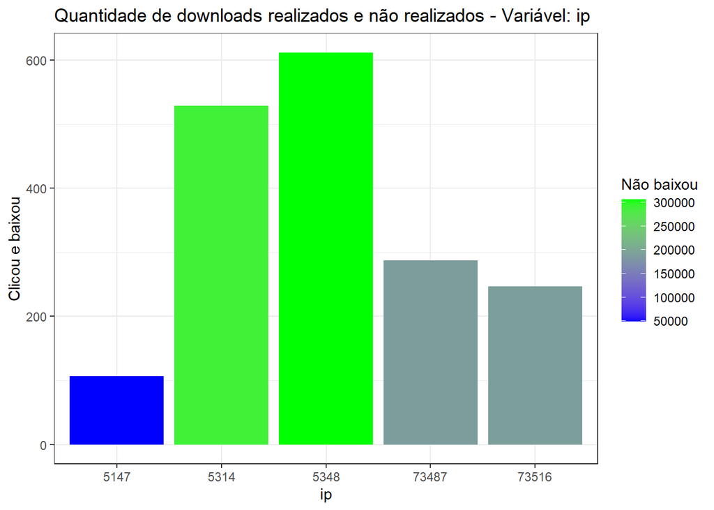

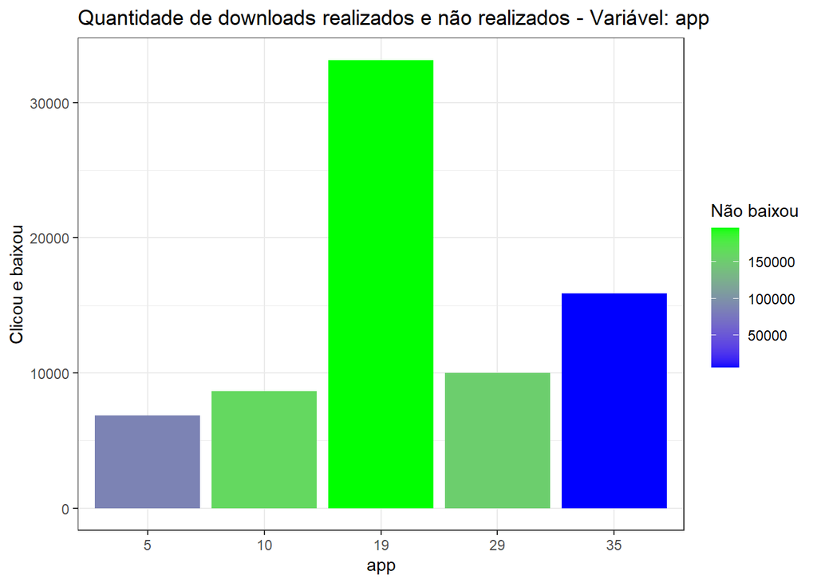

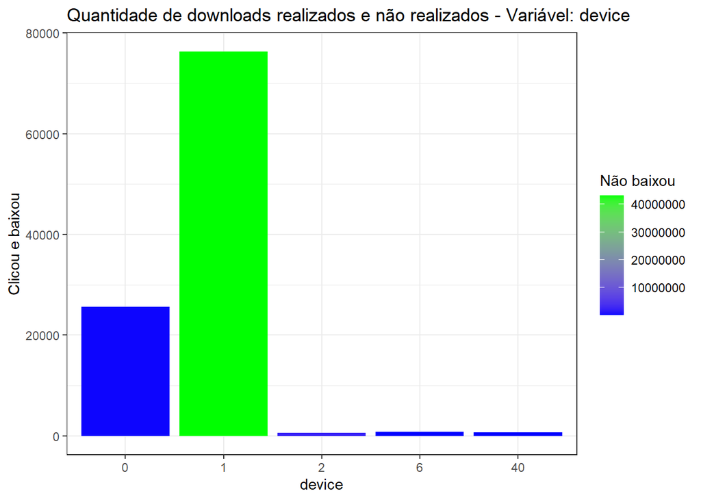

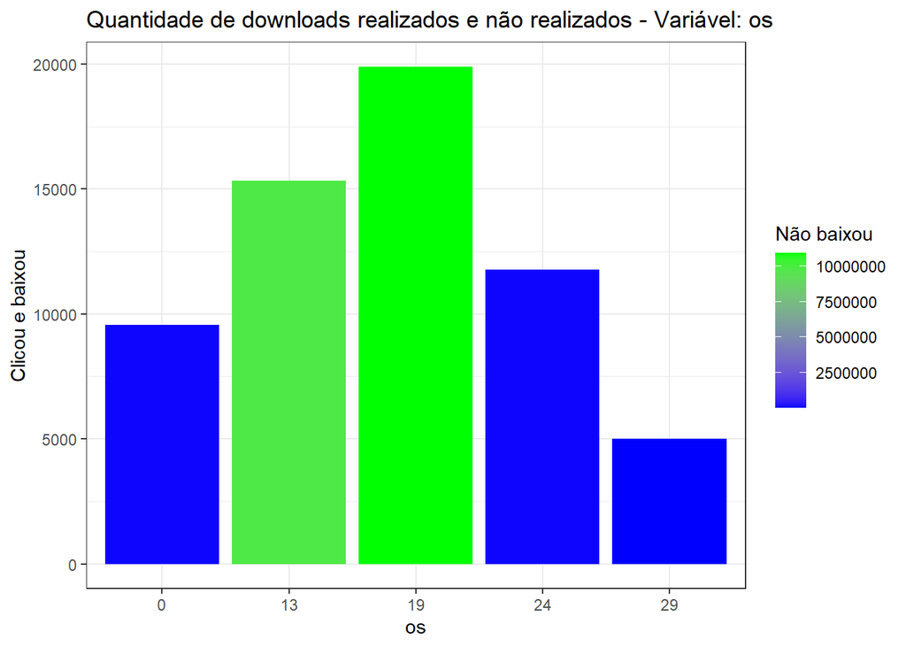

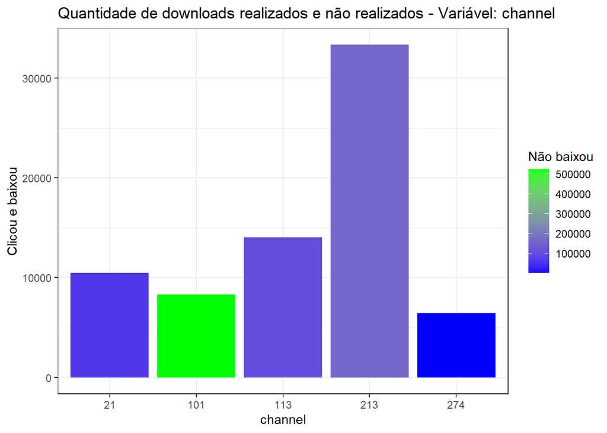

```r
# Gráfico de barras das observações que mais baixaram
bars_repetion(downloaded)
```

Podemos tirar algumas conclusões a respeito das informações acima. Abaixo tiraremos algumas informações daremos alguns inishgts a respeito do que pode ser feito:

**Variável ip:**

- Usuários que possuem mais cliques são: **5348** e **5314**, também são os usuários que mais possuem downloads realizados. Contudo, sua taxa de conversão é muito baixa, apenas 0,199 e 0,182, respectivamente.
- Dentre os 5 primeiro o ip **5147** é o que possui a melhor taxa de conversão: 0.216%, contudo sua quantidade total de cliques é bem inferior das demais.
  - **Insights:**
    - De acordo com nossos dados, os usuários apesar de clicarem nos anúncios normalmente não realizam downloads.
    - Averiguar o motivo do por que os usuários, embora tenham clicado nos anúncios, não chegam a fazer o download.
    - IP’s com quantidade muito alta de cliques, averiguar a possibilidade de serem robôs.

**Variável app:**

- Podemos verificar que nenhum dos aplicativos com mais cliques estão entre as 5 que mais tiveram downloads.
- App 35 foi o que obtivemos melhor resultado. De um total de 22.606 cliques, 15.870 tiveram downloads, 70.2% do total. Entretanto, seu total de cliques é o mais baixo.
- App 19 foi o que obteve a maior quantidade de downloads, 33.157, equivalem à 14.4% do total de cliques. Taxa razoável.
  - **Insights:**
    - Verificar o motivo dos apps: 3, 12 e 2 obterem tantos cliques sem downloads e se possível, interromper os anúncios através deles.
    - Analisar o diferencial do app 35 para conseguir mais conversão de downloads e aumentar a quantidade de anúncios dentro do app.
    - Analisar o o retorno referente ao app 19.

**Variável device:**

- Device 1 foi o que mais obteve cliques e também foi o que mais teve downloads. Entretanto, sua taxa de conversão é bem baixa, apenas 0,176% do total.
- Device 0 é o terceiro que mais possui cliques, entretanto ele está em segundo com quantidade total de donwloads. Sua taxa de conversão está razoável, 9,95%.
- Devices 6, 40, tiveram uma boa taxa de conversão, entretanto, a quantidade total de cliques realizados nesses aplicativos é muito baixa: 3.138, 3.061, respectivamente.
  - **Insights:**
    - Possibilidade de encerramento de anúncios pelo modelo 1.Grandes chances de existirem robôs que utilizam o modelo do tipo 1.
    - Verificar a possibilidade de aumentar os anúncios aos modelos 6, 40.
    - Interromper os anúncios do app 2. Praticamente 100% dos seus cliques não possuem downloads.

**Variável os (sistema operacional):**

- OS’s 19 e 13 são os que mais possuem cliques e também os que mais apresentaram downloads. No entanto, os downloads equivalem à apenas 0,181% e 0.155%, do total de cliques, respectivamente. Taxa de conversão muito baixa.
- OS’s 24, 0, 29 possuem uma taxa de conversão aproximada, um média de conversão de 14,23%. Porém possuem uma quantidade de cliques baixa.
  - **Insights:**
    - OS’s 19 e 13 possuem grandes chances de existirem robôs que os utilizem. Encerrar anúncios por eles.
    - Verificar a possibilidade de aumentar o número de anúncio aos OS’s 24, 0 e 29.

**Variável channel:**

- Nenhum dos canais com mais cliques estão entre os que mais tiveram downloads.
- Canal 274 possui uma alta taxa de conversão. 66,9%. Entretanto, apresenta um total de cliques muito baixo, apenas 9.616.
- O canal com mais downloads foi o 213, onde 17,1% do total de cliques foram convertidos.
- Os canais 113 e 21 possuem taxas de conversão parecidas. Contudo, o canal 113 possui cerca de 57% mais cliques que o 21, porém possui uma taxa de conversão inferior.
  - **Insights:**
    - Os canais que possuem mais cliques possuem taxa de conversão muito baixa. Uma vez que não aparecem entre os 5 canais que mais tiveram downlodas. Verificar possibilidade de cancelar os anúncios realizados por esses canais.
    - Verificar a possibilidade de aumentar os anúncios aos canais 21 e 274.

Vamos verificar agora as 5 primeiras observações que menos fizeram downloads.

```r
# Criando uma variável com as observações.
n_downloaded <- y_no(ord=2)

# Visualizando as informações.
n_downloaded
```

```
## [[1]]
## # A tibble: 5 x 6
##   ip    baixou n_baixou baixou_percent n_baixou_percent total_cliques
##   <fct>  <int>    <int>          <dbl>            <dbl>         <int>
## 1 5348     612   306953          0.199             99.8        307565
## 2 5314     529   290567          0.182             99.8        291096
## 3 73516    247   191360          0.129             99.9        191607
## 4 73487    287   190041          0.151             99.8        190328
## 5 53454     25   123528          0.02             100.         123553
##
## [[2]]
## # A tibble: 5 x 6
##   app   baixou n_baixou baixou_percent n_baixou_percent total_cliques
##   <fct>  <int>    <int>          <dbl>            <dbl>         <int>
## 1 3       2585  8416930          0.031            100.        8419515
## 2 12       626  5997120          0.01             100.        5997746
## 3 2       1394  5398011          0.026            100.        5399405
## 4 9       4581  4099163          0.112             99.9       4103744
## 5 15       849  3982141          0.021            100.        3982990
##
## [[3]]
## # A tibble: 5 x 6
##   device baixou n_baixou baixou_percent n_baixou_percent total_cliques
##   <fct>   <int>    <int>          <dbl>            <dbl>         <int>
## 1 1       76361 43283469          0.176             99.8      43359830
## 2 2         576  2014573          0.029            100.        2015149
## 3 0       25582   231435          9.95              90.0        257017
## 4 3032        1   172618          0.001            100.         172619
## 5 3543        1    66945          0.001            100.          66946
##
## [[4]]
## # A tibble: 5 x 6
##   os    baixou n_baixou baixou_percent n_baixou_percent total_cliques
##   <fct>  <int>    <int>          <dbl>            <dbl>         <int>
## 1 19     19905 10971838          0.181             99.8      10991743
## 2 13     15328  9871814          0.155             99.8       9887142
## 3 17      2855  2392433          0.119             99.9       2395288
## 4 18      2840  2227346          0.127             99.9       2230186
## 5 22      3305  1841737          0.179             99.8       1845042
##
## [[5]]
## # A tibble: 5 x 6
##   channel baixou n_baixou baixou_percent n_baixou_percent total_cliques
##   <fct>    <int>    <int>          <dbl>            <dbl>         <int>
## 1 280       1021  3716086          0.027            100.        3717107
## 2 245        209  2211497          0.009            100.        2211706
## 3 107       1072  2103738          0.051             99.9       2104810
## 4 477        301  1791954          0.017            100.        1792255
## 5 134        846  1473019          0.057             99.9       1473865
```

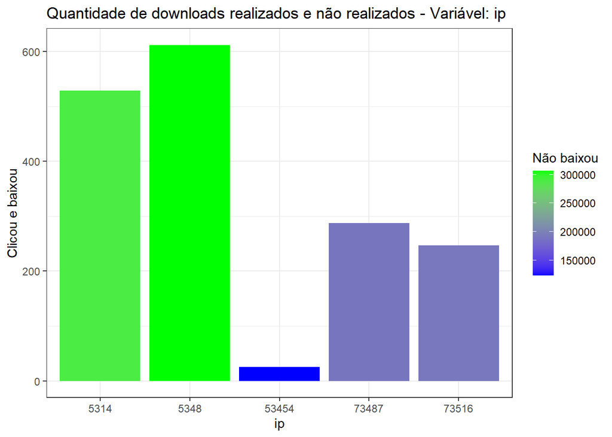

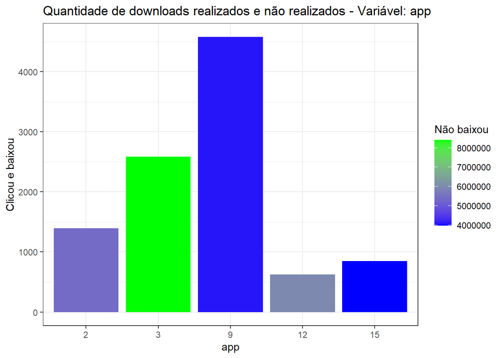

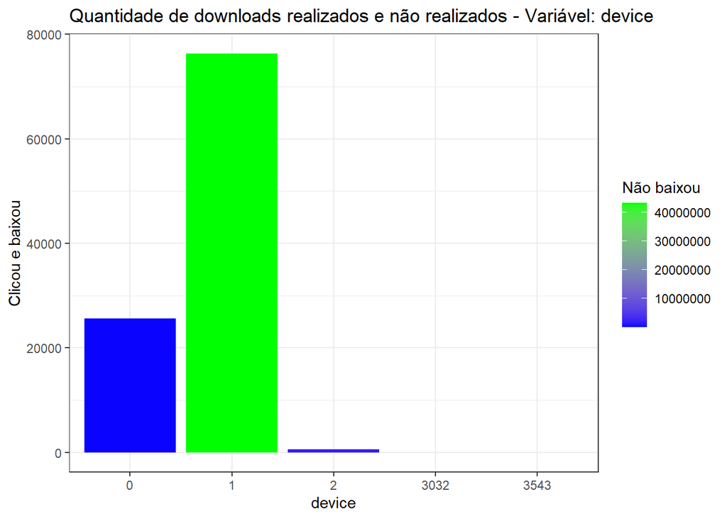

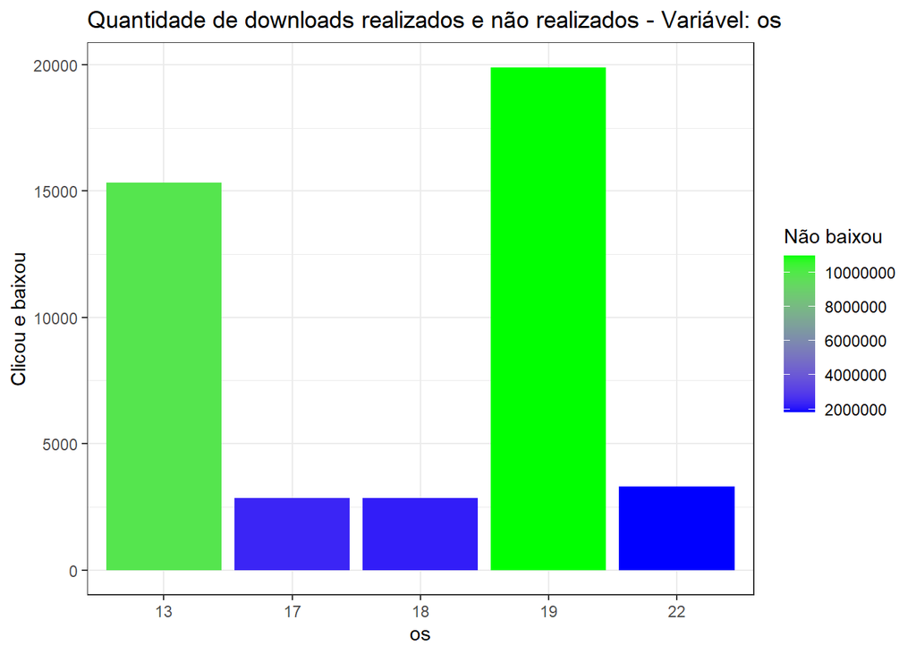

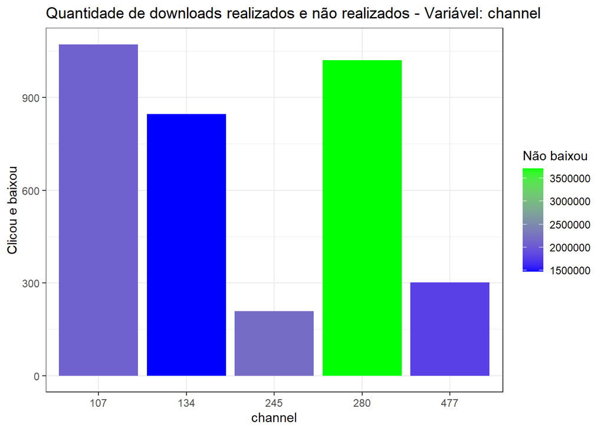

```r
# Gráfico de barras das observações que menos baixaram
bars_repetion(n_downloaded)
```

```r
# Comparando cada uma das variáveis para tirarmos conclusões mais precisas.
for (i in seq(downloaded)){
  print(downloaded[i])
  print(n_downloaded[i])
  cat('\n\n\n\n')
}
```

```
## [[1]]
## # A tibble: 5 x 6
##   ip    baixou n_baixou baixou_percent n_baixou_percent total_cliques
##   <fct>  <int>    <int>          <dbl>            <dbl>         <int>
## 1 5348     612   306953          0.199             99.8        307565
## 2 5314     529   290567          0.182             99.8        291096
## 3 73487    287   190041          0.151             99.8        190328
## 4 73516    247   191360          0.129             99.9        191607
## 5 5147     107    49331          0.216             99.8         49438
##
## [[1]]
## # A tibble: 5 x 6
##   ip    baixou n_baixou baixou_percent n_baixou_percent total_cliques
##   <fct>  <int>    <int>          <dbl>            <dbl>         <int>
## 1 5348     612   306953          0.199             99.8        307565
## 2 5314     529   290567          0.182             99.8        291096
## 3 73516    247   191360          0.129             99.9        191607
## 4 73487    287   190041          0.151             99.8        190328
## 5 53454     25   123528          0.02             100.         123553
##
##
##
##
##
## [[1]]
## # A tibble: 5 x 6
##   app   baixou n_baixou baixou_percent n_baixou_percent total_cliques
##   <fct>  <int>    <int>          <dbl>            <dbl>         <int>
## 1 19     33157   196466          14.4              85.6        229623
## 2 35     15870     6736          70.2              29.8         22606
## 3 29     10011   152826           6.15             93.9        162837
## 4 10      8642   162482           5.05             95.0        171124
## 5 5       6845    87147           7.28             92.7         93992
##
## [[1]]
## # A tibble: 5 x 6
##   app   baixou n_baixou baixou_percent n_baixou_percent total_cliques
##   <fct>  <int>    <int>          <dbl>            <dbl>         <int>
## 1 3       2585  8416930          0.031            100.        8419515
## 2 12       626  5997120          0.01             100.        5997746
```

[output cut: 60 more lines]

```
## 1 213      33378   161456          17.1              82.9        194834
## 2 113      14030   104842          11.8              88.2        118872
## 3 21       10469    64941          13.9              86.1         75410
## 4 101       8295   524740           1.56             98.4        533035
## 5 274       6437     3179          66.9              33.1          9616
##
## [[1]]
## # A tibble: 5 x 6
##   channel baixou n_baixou baixou_percent n_baixou_percent total_cliques
##   <fct>    <int>    <int>          <dbl>            <dbl>         <int>
## 1 280       1021  3716086          0.027            100.        3717107
## 2 245        209  2211497          0.009            100.        2211706
## 3 107       1072  2103738          0.051             99.9       2104810
## 4 477        301  1791954          0.017            100.        1792255
## 5 134        846  1473019          0.057             99.9       1473865
```

**IP:**

- Podemos ver que os quatro usuários que mais baixaram também são os usuários que menos baixaram. Isso é possível por terem uma quantidade de cliques muito grande.
- Averiguar o motivo desses ip’s terem tantos cliques e não realizarem downloads.

**APP:**

- Nenhum dos app’s que mais baixaram estão entre os que mais possuem downloads. E os que menos baixaram são os que mais tiveram cliques.
- Interromper anúncios através desses app’s.

**DEVICE:**

- O device 1 é que mais baixou e o que menos baixou. Averiguar o motivo de tantos cliques serem realizados por esse modelo. Número
- muito discrepante. E verificar possibilidade de interromper anúncios por esse modelo.
- O device 0 está tanto entre os que mais baixaram e os que menos baixaram, porém possui uma taxa de conversão considerável. Averiguar informações mais detalhadas a respeito do modelo.
- Encerrar anúncios aos modelos 3032, 2 e 3543.

**OS:**

- os’s 19 e 13 são os que mais baixaram e também os que menos baixaram, e possuem taxa de conversão muito baixa. Validada encerramento de anúncio por eles.
- Encerrar anúncios aos os’s 17, 18 e 22.

**CHANNEL:**

- Encerrar anúncios realizados pelos canais: 280, 245, 107, 477 e 134.

Vamos verificar os 5 registros de cada variável que tiveram a maior taxa de conversão.

```r
# Criando uma variável para visualizarmos as informações.
by_percent <- lapply(conames[1:5], function(cols){
  train_data[,c(cols,'is_attributed'), with=F] %>% group_by(across(cols)) %>%
    summarise(baixou = sum(is_attributed==1),
              n_baixou = sum(is_attributed==0),
              baixou_percent = round(100*baixou/(baixou+n_baixou), digits = 3),
              n_baixou_percent = round(100*n_baixou/(baixou+n_baixou), digits = 3),
              total_linhas = baixou+n_baixou) %>%
    arrange(desc(baixou_percent)) %>%
    head(5)
})

# Visualizando as informações.
by_percent
```

```
## [[1]]
## # A tibble: 5 x 6
##   ip    baixou n_baixou baixou_percent n_baixou_percent total_linhas
##   <fct>  <int>    <int>          <dbl>            <dbl>        <int>
## 1 230        1        0            100                0            1
## 2 360        1        0            100                0            1
## 3 756        1        0            100                0            1
## 4 943        1        0            100                0            1
## 5 1229       2        0            100                0            2
##
## [[2]]
## # A tibble: 5 x 6
##   app   baixou n_baixou baixou_percent n_baixou_percent total_linhas
##   <fct>  <int>    <int>          <dbl>            <dbl>        <int>
## 1 350        1        0            100                0            1
## 2 359        1        0            100                0            1
## 3 441        1        0            100                0            1
## 4 559        1        0            100                0            1
## 5 615        1        0            100                0            1
##
## [[3]]
## # A tibble: 5 x 6
##   device baixou n_baixou baixou_percent n_baixou_percent total_linhas
##   <fct>   <int>    <int>          <dbl>            <dbl>        <int>
## 1 228         2        0            100                0            2
## 2 355         1        0            100                0            1
## 3 633         1        0            100                0            1
## 4 683         1        0            100                0            1
## 5 705         1        0            100                0            1
##
## [[4]]
## # A tibble: 5 x 6
##   os    baixou n_baixou baixou_percent n_baixou_percent total_linhas
##   <fct>  <int>    <int>          <dbl>            <dbl>        <int>
## 1 658        1        0          100               0               1
## 2 733        1        0          100               0               1
## 3 61      1385      108           92.8             7.23         1493
## 4 242        3        2           60              40               5
## 5 314        1        1           50              50               2
##
## [[5]]
## # A tibble: 5 x 6
##   channel baixou n_baixou baixou_percent n_baixou_percent total_linhas
##   <fct>    <int>    <int>          <dbl>            <dbl>        <int>
## 1 408        168        8           95.5             4.54          176
## 2 114        142        7           95.3             4.70          149
## 3 465        643      273           70.2            29.8           916
## 4 274       6437     3179           66.9            33.1          9616
## 5 419       1700      911           65.1            34.9          2611
```

Vamos verificar se existem horários em que um click e um download são iguais. Caso exista algum, as chances de ter sido clicado por um bot são altas, devido ao fato de que um usuário difícilmente seria tão rápido.

```r
# Crando as variáveis com as linhas onde o tempo do clique foi igual ao download.
clickTime_downTime <- train_data[train_data[['click_time']]==train_data[['attributed_time']]]

# verificando a quantidade de registros co tempos iguais.
nrow(clickTime_downTime)
```

```
## [1] 107
```

Podemos verificar que temos apenas 107 linhas em que os dois horários são iguais. Salvaremos as informações num arquivo csv para análises mais detalhadas e removeremos essas linhas de nosso dataset.

```r
# Criando arquivo .csv
fwrite(clickTime_downTime, 'clickTime_downTime.csv')

# Criando uma variável com os indices das linhas a serem removidas
lns <- which(train_data[['click_time']]==train_data[['attributed_time']])

# Removendo as linhas
train_data <- train_data[-lns,]

# Validando a remoção das linhas
nrow(train_data[train_data[['click_time']]==train_data[['attributed_time']]])
```

```
## [1] 0
```

Antes de analisarmos a quantidade de cliques através do tempo, vamos verificar as datas de início e fim que estamos trabalhando.

```r
# Verificando o intervalo entre as datas.
interval(as.Date(min(train_data$click_time)), as.Date(max(train_data$click_time)))
```

```
## [1] 2017-11-06 UTC--2017-11-09 UTC
```

Podemos verificar que o dataset possui uma quantidade de cliques que vai do dia 06 à 09 de novembro de 2017.

Vamos analisar em qual horário do dia existem mais cliques realizados.

Criaremos uma variável utilizando apenas as horas da coluna **click_time** para geração do gráfico temporal.

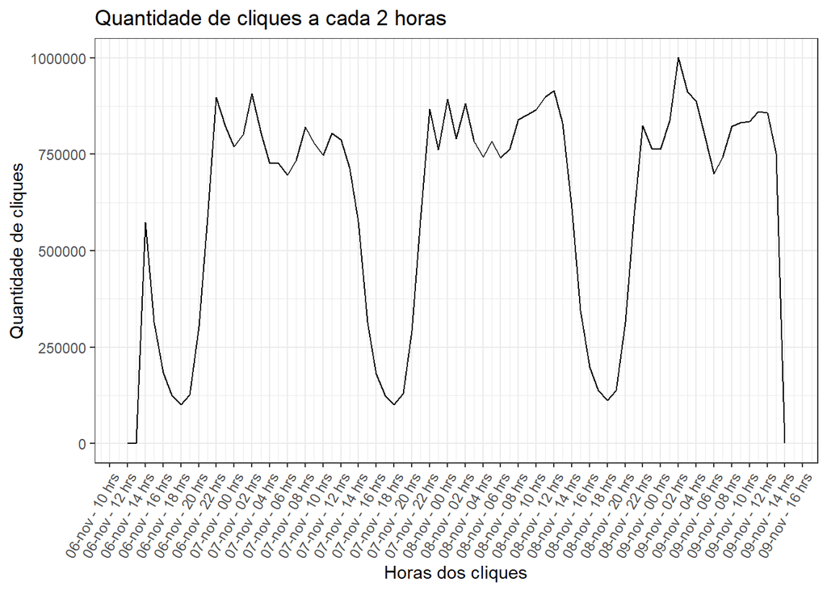

```r
# Criando uma variável apenas com as horas da coluna click_time.
click_hour <- data.frame(data_hora = floor_date(train_data[['click_time']], unit='hour'))

# Criando o gráfico temporal para visualizarmos os cliques ao longo do tempo.
click_hour %>%
  group_by(data_hora) %>% summarise(cliques_hora = n()) %>%
  ggplot(aes(data_hora, cliques_hora)) +
  geom_line() +
  scale_x_datetime(date_breaks = '2 hours', date_labels = '%d-%b - %H hrs') +
  theme_bw() +
  theme(axis.text.x = element_text(angle = 60, hjust = 1)) +
  xlab('Horas dos cliques') +
  ylab('Quantidade de cliques') +
  ggtitle('Quantidade de cliques a cada 2 horas')
```

Aqui seria interessante diminuir os gatos com anúncios nos horários onde vemos claramente uma queda nos cliques e aumentar a quantidade de anúncios nos horários onde vemos uma alta nos cliques.

Vamos analisar em qual horário do dia houve mais downloads.

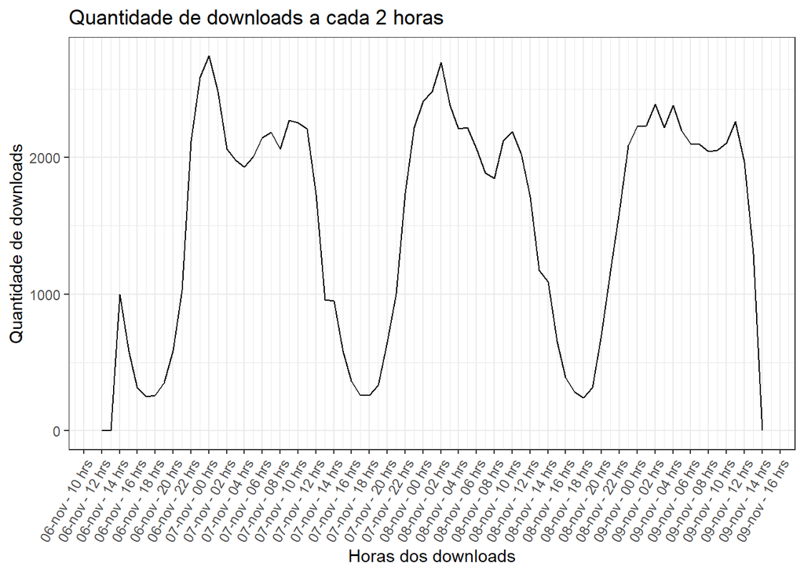

```r
# Criando uma variável com a variável 'is_attributed'.
click_hour['is_attributed'] <- train_data[['is_attributed']]

# Criando o gráfico temporal.
click_hour %>%
  group_by(data_hora) %>% summarise(downloads_hora = sum(is_attributed==1)) %>%
  ggplot(aes(data_hora, downloads_hora)) +
  geom_line() +
  scale_x_datetime(date_breaks = '2 hours', date_labels = '%d-%b - %H hrs') +
  theme_bw() +
  theme(axis.text.x = element_text(angle = 60, hjust = 1)) +
  xlab('Horas dos downloads') +
  ylab('Quantidade de downloads') +
  ggtitle('Quantidade de downloads a cada 2 horas')
```

Vamos analisar em qual horário do dia **NÃO** houve download.

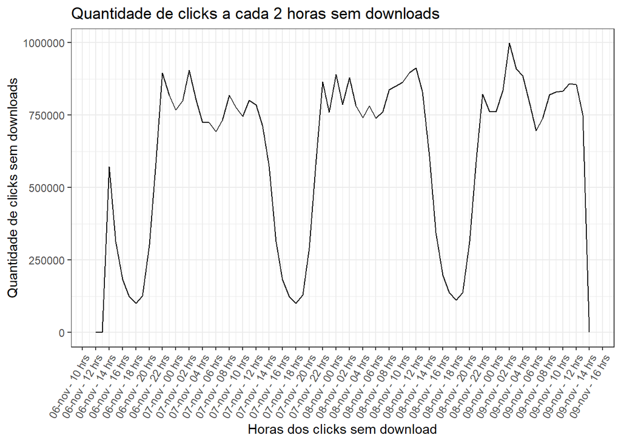

```r
# Gerando o gráfico temporal dos cliques sem downloads.
click_hour %>%
  group_by(data_hora) %>% summarise(sem_download = sum(is_attributed==0)) %>%
  ggplot(aes(data_hora, sem_download)) +
  geom_line() +
  scale_x_datetime(date_breaks = '2 hours', date_labels = '%d-%b - %H hrs') +
  theme_bw() +
  theme(axis.text.x = element_text(angle = 60, hjust = 1)) +
  xlab('Horas dos clicks sem download') +
  ylab('Quantidade de clicks sem downloads') +
  ggtitle('Quantidade de clicks a cada 2 horas sem downloads')
```

Aqui podemos ver que a quantidade de cliques sem downloads é muito similar aos cliques totais gerados. Isso se deve ao fato de que apenas 114.101 downloads de um total de 45.989.635 cliques.

## **4. Modelagem Preditiva.**

Vamos iniciar nosso processo de modelagem preditiva. Antes de realizarmos o treinamento do modelo precisamos verificar se nossa variável target **is_attributed** está com seus valores equilibrados.

```r
# Verificando o percentrual dos valores da variável target 'is_attributed'
round(prop.table(table(factor(train_data$is_attributed, labels = c('Sem_download', 'Download')))), digits = 4)
```

```
##
## Sem_download     Download
##       0.9975       0.0025
```

Conforme tabela acima conseguimos perceber que nossa variável que queremos prever está totalmente desbalanceada. Temos muitos mais cliques sem downloads do que cliques com download. Isso é um problema pois faz o algoritmo ter problema de overfitting, onde não conseguiremos generalizá-lo, ou seja, utilizá-lo em outros conjuntos de dados.

Vamos verificar a informação num gráfico de barras.

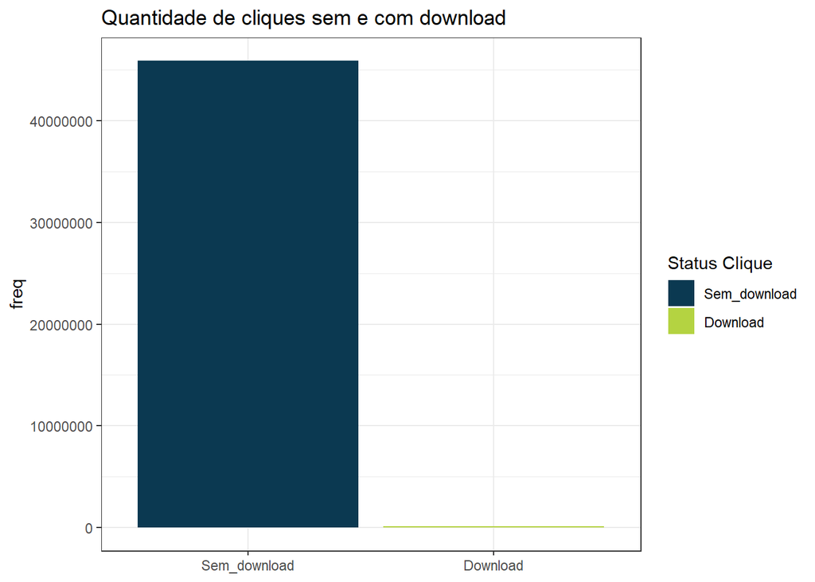

```r
# Criando um gráfico de barras para visualizarmos o desbalanceamento.
click_hour['is_attributed'] %>%  mutate(factorized = factor(is_attributed, labels = c('Sem_download', 'Download'))) %>% count(factorized, name = 'freq') %>%
  ggplot(aes(x=factorized, y=freq, fill=factorized)) +
  geom_bar(stat = 'identity') +
  scale_fill_manual(values=c("#0B3951", "#B4D341")) +
  theme_bw() +
  labs(fill='Status Clique', title='Quantidade de cliques sem e com download', ylab='Qntd de cliques') +
  theme(axis.title.x=element_blank())
```

No gráfico fica claro o desbalanceamento da variável. Para seguirmos à modelagem preditiva e criarmos nosso modelo de machine learning, precisaremos primeiramente balancear a variável is_attributed (target - o que queremos prever) e para isso utilizaremos o pacote **ROSE**.

Para realizarmos as análises fizemos a conversão das variáveis para fator e datatempo, porém o pacote **ROSE** não permite utilizarmos valores **NA** para balanceamento. Como realizar a conversão das variáveis datatempo para fator leva muito tempo para processamento optei em remover os dados e recarregá-los novamente, para conversão em fator.

```r
# Removendo os dados de treino e o dataset criado.
rm(train_data)
rm(click_hour)
```

Antes de realizarmos o balanceamento da variável, faremos a separação dos dados em dados de treino e dados de teste. Para realizarmos o treinamento do nosso modelo de machine learning, utilizaremos apenas 1/30 do total de linhas dos dados, devido à insuficiência de memória para processamento.

```r
# recarregando a amostra.
train_data <- fread('train_sample.csv')

# Lendo 1/30 das linhas para treinamento do modelo.
subset_1 <- train_data[sample(1:nrow(train_data), round(nrow(train_data)/30)),]

# Verificando o número de linhas.
nrow(subset_1)

# Removendo os dados de treino desbalanceados.
rm(train_data)

# Salvando os novos dados num arquivo csv.
fwrite(subset_1, 'subset_1.csv')

# Criando uma variável para a divisão em 80% dados de treino e 20% em dados de teste.
divisao <- sample(1:nrow(subset_1), 0.8 * nrow(subset_1))

# Realizando a divisão dos dados
dados_treino <- subset_1[divisao,]
dados_teste <- subset_1[-divisao,]

# Removendo o dataset sem a separação dos dados e variável contendo as linhas da separação para liberar espaço de memória.
rm(subset_1)
rm(divisao)

# Salvando os dados separados em arquivos csv.
fwrite(dados_treino, 'dados_treino.csv')
fwrite(dados_teste, 'dados_teste.csv')
```

Vamos verificar se há desbalanceamento na variável target nos dados de treino e teste.

**Dados de Treino:**

```r
# Validando desbalanceamento nos dados de treino.
round(prop.table(table(factor(dados_treino$is_attributed, labels = c('Sem_download', 'Download')))), digits = 4)
```

```
##
## Sem_download     Download
##       0.9974       0.0026
```

**Dados de Teste:**

```r
# Validando desbalanceamento nos dados de Teste.
round(prop.table(table(factor(dados_teste$is_attributed, labels = c('Sem_download', 'Download')))), digits = 4)
```

```
##
## Sem_download     Download
##       0.9975       0.0025
```

Conforme pudemos ver tantos os dados de treino quanto os de teste apresentam desbalanceamento. Precisaremos balacenar os dados para podermos utilizá-los na criação do modelo de machine learning.

Para conseguirmos realizar as conversões o pacote **ROSE** requer que as variáveis estejam como **fator**. Dessa forma, faremos a conversão e criaremos os novos conjuntos de dados balanceados.

```r
# Transformando as variáveis em fator
for (i in colnames(dados_treino)){
  dados_treino[[i]] <- as.factor(dados_treino[[i]])
  dados_teste[[i]] <- as.factor(dados_teste[[i]])
}

# balanceando a variável target (is_attributed) nos conjuntos de dados de treino e teste.
rose_treino <- ROSE(is_attributed ~ ., data=dados_treino)$data
rose_teste <- ROSE(is_attributed ~ ., data=dados_teste)$data

# Removendo os dados desbalanceadas da memória.
rm(dados_treino)
rm(dados_teste)

# Gravando os dados balanceados num arquivo csv
fwrite(rose_treino, 'rose_treino.csv')
fwrite(rose_teste, 'rose_teste.csv')
```

Vamos validar o balanceamento da variável nos dados de treino e teste.

**Dados de Treino:**

```r
# Validando o balanceamento.
round(prop.table(table(factor(rose_treino$is_attributed, labels = c('Sem_download', 'Download')))), digits = 4)
```

```
##
## Sem_download     Download
##       0.4999       0.5001
```

**Dados de Teste:**

```r
# Validando o desbalanceamento.
round(prop.table(table(factor(rose_teste$is_attributed, labels = c('Sem_download', 'Download')))), digits = 4)
```

```
##
## Sem_download     Download
##       0.5006       0.4994
```

Como pudemos ver estamos com uma ótima proporção, quase 50% à 50% em ambos os datasets.

Criaremos algumas variáveis dentro do dataset que nos ajudarão na eficácia do algoritmo. Farei a remoção e releitura dos dados balanceados para que as variáveis venham com suas classes originais.

```r
# Removendo os dados de treino e teste.
rm(rose_treino)
rm(rose_teste)
```

Vamos utilizar primeiramente os dados de treino para criarmos o modelo.

```r
# Recarregando os dados de treino.
rose_treino <- fread('rose_treino.csv')
```

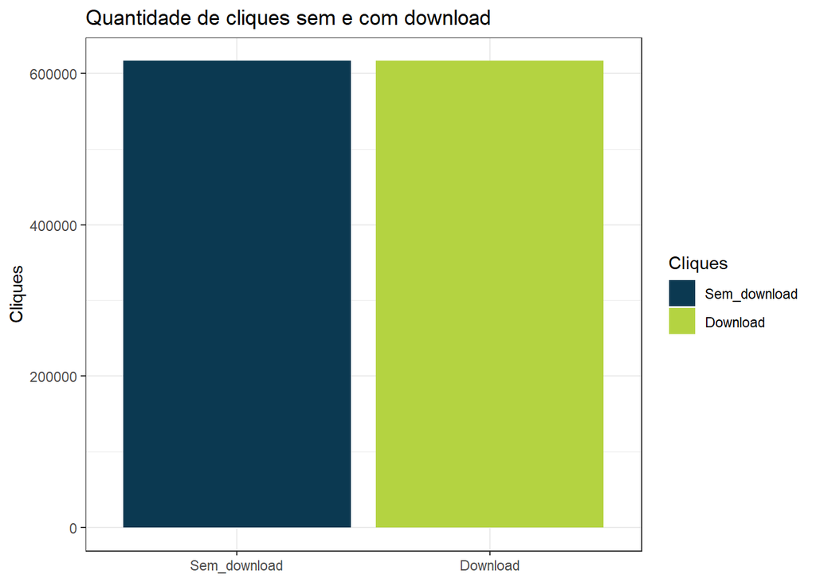

```r
# Confirmando o balanceamento através de um gráfico de barras.
rose_treino[,'is_attributed'] %>%  mutate(factorized = factor(is_attributed, labels = c('Sem_download', 'Download'))) %>%
  count(factorized, name = 'Cliques') %>%
  ggplot(aes(x=factorized, y=Cliques, fill=factorized)) +
  geom_bar(stat = 'identity') +
  scale_fill_manual(values=c("#0B3951", "#B4D341")) +
  theme_bw() +
  labs(fill='Cliques', title='Quantidade de cliques sem e com download', ylab='Qntd de cliques') +
  theme(axis.title.x=element_blank())
```

```r
# Faremos a criação de algumas variáveis que considero que ajudarão o algoritmo a ter uma melhor acurácia.
rose_treino <- rose_treino %>%
  mutate(day = day(click_time), hour = hour(click_time)) %>%
  add_count(hour, os, name = 'HoraOs') %>%
  add_count(hour, device, name = 'HoraDevice') %>%
  add_count(hour, app, name = 'HoraApp') %>%
  add_count(hour, channel, name = 'HoraCanal') %>%
  add_count(hour, day,  name = 'HoraDay') %>%
  add_count(app, channel,  name = 'AppCanal') %>%
  add_count(device, os,  name = 'ModeloOs') %>%
  add_count(channel, app, hour,  name = 'CanalApp') %>%
  add_count(device, channel,  name = 'ModeloCanal') %>%
  select(-c(click_time, attributed_time, ip))
```

```r
# Salvando o subset num arquivo csv.
fwrite(rose_treino, 'subset_treino.csv')
```

### 4.1 Algoritmo Random Forest.

Utilizaremos o algoritmo Random Forest para analisarmos quais as variáveis mais importantes ao modelo. Pode-se optar pelo modelo **Accuracy** ou o modelo **Gini**.

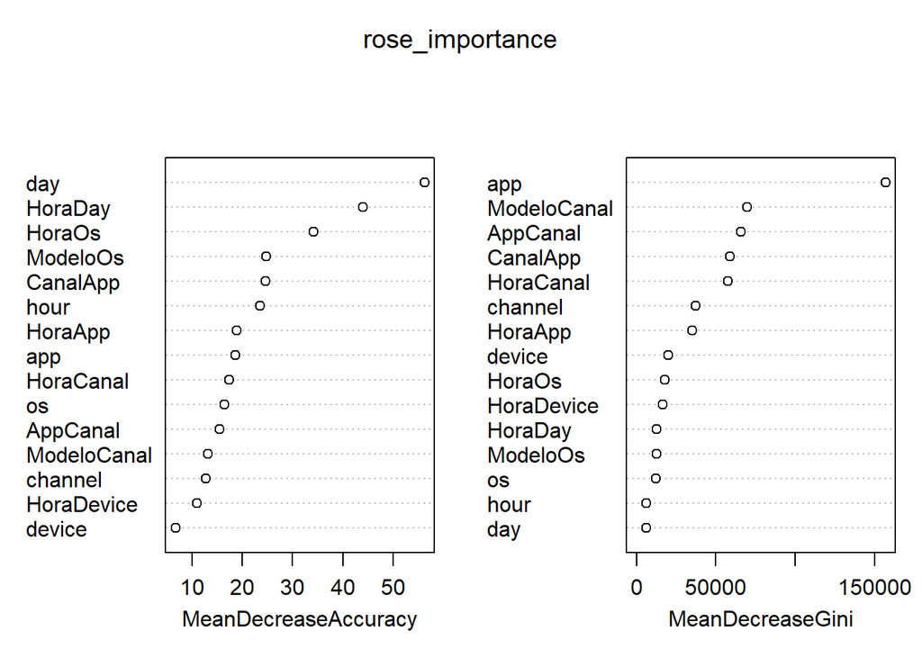

```r
# Transformando a variável target em fator.
rose_treino[["is_attributed"]] <- as.factor(rose_treino[["is_attributed"]])

# Criando um modelo para sabermos quais as variáveis que mais importam para acurácia do algoritmo
rose_importance <- randomForest(is_attributed ~ .,
                                data = rose_treino,
                                ntree = 40,
                                nodesize = 2,
                                importance = T)

# visualizando as variáveis mais importantes.
varImpPlot(rose_importance)
```

Podemos ver claramente quais as variáveis mais importantes. Contudo, utilizaremos todas as variáveis para criação dos modelos.

```r
# Removendo modelo das variáveis mais importantes.
rm(rose_importance)
```

Vamos realizar o treinamento do modelo Random Forest.

```r
# Criando uma fórmula para seleção das variáveis.
forms <- as.formula(is_attributed ~ .)

# Criando o modelo.
modelo_forest <- randomForest(forms,
                              data = rose_treino,
                              ntree = 40,
                              nodesize = 2)

# Visualizando o modelo.
modelo_forest
```

```
##
## Call:
##  randomForest(formula = forms, data = rose_treino, ntree = 40,      nodesize = 2)
##                Type of random forest: classification
##                      Number of trees: 40
## No. of variables tried at each split: 3
##
##         OOB estimate of  error rate: 1.13%
## Confusion matrix:
##        0      1 class.error
## 0 604994  11264 0.018278059
## 1   2617 613817 0.004245386
```

Pudemos ver que a **taxa de erro** do modelo relacionada aos dados de treino está em torno de 1%.

Vamos carregar nossos dados de teste para avaliarmos nosso modelo criado com o algoritmo **Random Forest**.

Para conseguirmos realizar as predições precisaremos fazer as mesmas alterações nos dados de teste que fizemos aos dados de treino.

```r
# Lendo os dados de teste para testarmos o modelo.
rose_teste <- fread('rose_teste.csv')
```

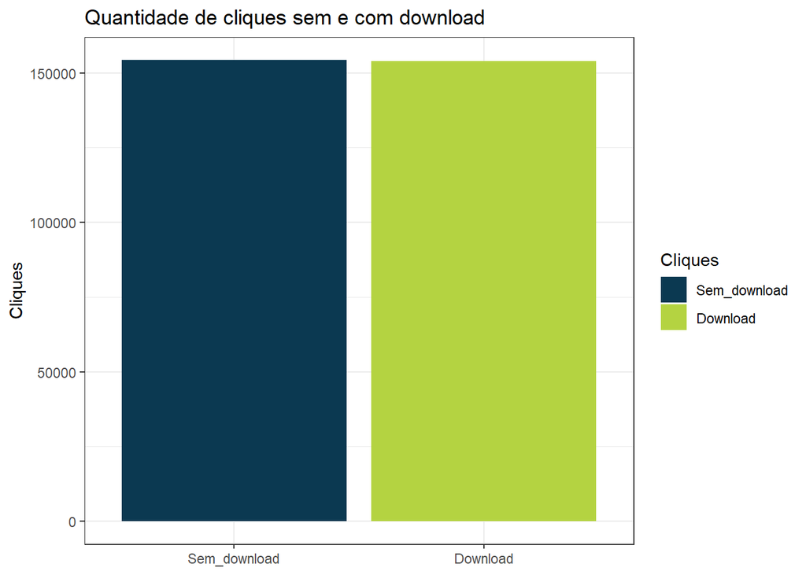

```r
# Confirmando o balanceamento através de um gráfico de barras.
rose_teste[,'is_attributed'] %>%  mutate(factorized = factor(is_attributed, labels = c('Sem_download', 'Download'))) %>%
  count(factorized, name = 'Cliques') %>%
  ggplot(aes(x=factorized, y=Cliques, fill=factorized)) +
  geom_bar(stat = 'identity') +
  scale_fill_manual(values=c("#0B3951", "#B4D341")) +
  theme_bw() +
  labs(fill='Cliques', title='Quantidade de cliques sem e com download', ylab='Qntd de cliques') +
  theme(axis.title.x=element_blank())
```

```r
# Faremos a criação de algumas variáveis que considero que ajudarão o algoritmo a ter uma melhor acurácia.
rose_teste <- rose_teste %>%
  mutate(day = day(click_time), hour = hour(click_time)) %>%
  add_count(hour, os, name = 'HoraOs') %>%
  add_count(hour, device, name = 'HoraDevice') %>%
  add_count(hour, app, name = 'HoraApp') %>%
  add_count(hour, channel, name = 'HoraCanal') %>%
  add_count(hour, day,  name = 'HoraDay') %>%
  add_count(app, channel,  name = 'AppCanal') %>%
  add_count(device, os,  name = 'ModeloOs') %>%
  add_count(channel, app, hour,  name = 'CanalApp') %>%
  add_count(device, channel,  name = 'ModeloCanal') %>%
  select(-c(click_time, attributed_time, ip))

# Gravando os dados num arquivo csv.
fwrite(rose_teste, 'subset_teste.csv')
```

```r
# Realizando as predições
predict_forest <- predict(modelo_forest, rose_teste[,-'is_attributed'])
```

Vamos avaliar o modelo de machine learning utilizando uma **Confusion Matrix**.

```r
# Criando uma confusion matrix para avaliação do modelo.
confusionMatrix(table(dados = rose_teste$is_attributed,
                      pred = predict_forest), positive = '1')
```

```
## Confusion Matrix and Statistics
##
##      pred
## dados      0      1
##     0 153964    316
##     1  92135  61759
##
##                Accuracy : 0.7
##                  95% CI : (0.6984, 0.7016)
##     No Information Rate : 0.7986
##     P-Value [Acc > NIR] : 1
##
##                   Kappa : 0.3996
##
##  Mcnemar's Test P-Value : <0.0000000000000002
##
##             Sensitivity : 0.9949
##             Specificity : 0.6256
##          Pos Pred Value : 0.4013
##          Neg Pred Value : 0.9980
##              Prevalence : 0.2014
##          Detection Rate : 0.2004
##    Detection Prevalence : 0.4994
##       Balanced Accuracy : 0.8103
##
##        'Positive' Class : 1
##
```

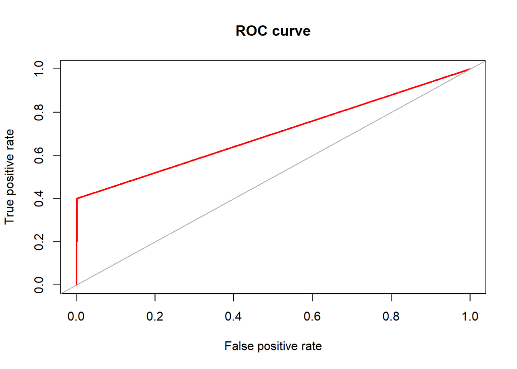

```
## Area under the curve (AUC): 0.700
```

```r
# Verificando a AUC.
roc.curve(rose_teste$is_attributed, predict_forest, plotit = T, col = "red")
```

Conforme mostra a **Confusion Matrix** o acurácia de nosso modelo está acima de 70% e a **AUC** também.

Vamos utilizar um algoritmo diferente para ver se conseguimos um melhor resultado.

### 4.2 Algoritmo Rpart.

Vamos criar um modelo preditivo utilizando o algoritmo **Rpart**.

```r
# Criando o model com o algoritmo rpart.
modelo_rf = rpart(forms, data = rose_treino, control = rpart.control(cp = .0005))

# Previsões nos dados de teste
predict_rf = predict(modelo_rf, rose_teste[,-'is_attributed'], type='class')

# Criando uma confusion matrix para avaliação do modelo.
confusionMatrix(table(dados = rose_teste$is_attributed,
                      pred = predict_rf), positive = '1')
```

```
## Confusion Matrix and Statistics
##
##      pred
## dados      0      1
##     0 138165  16115
##     1  14496 139398
##
##                Accuracy : 0.9007
##                  95% CI : (0.8996, 0.9017)
##     No Information Rate : 0.5046
##     P-Value [Acc > NIR] : < 0.00000000000000022
##
##                   Kappa : 0.8013
##
##  Mcnemar's Test P-Value : < 0.00000000000000022
##
##             Sensitivity : 0.8964
##             Specificity : 0.9050
##          Pos Pred Value : 0.9058
##          Neg Pred Value : 0.8955
##              Prevalence : 0.5046
##          Detection Rate : 0.4523
##    Detection Prevalence : 0.4994
##       Balanced Accuracy : 0.9007
##
##        'Positive' Class : 1
##
```

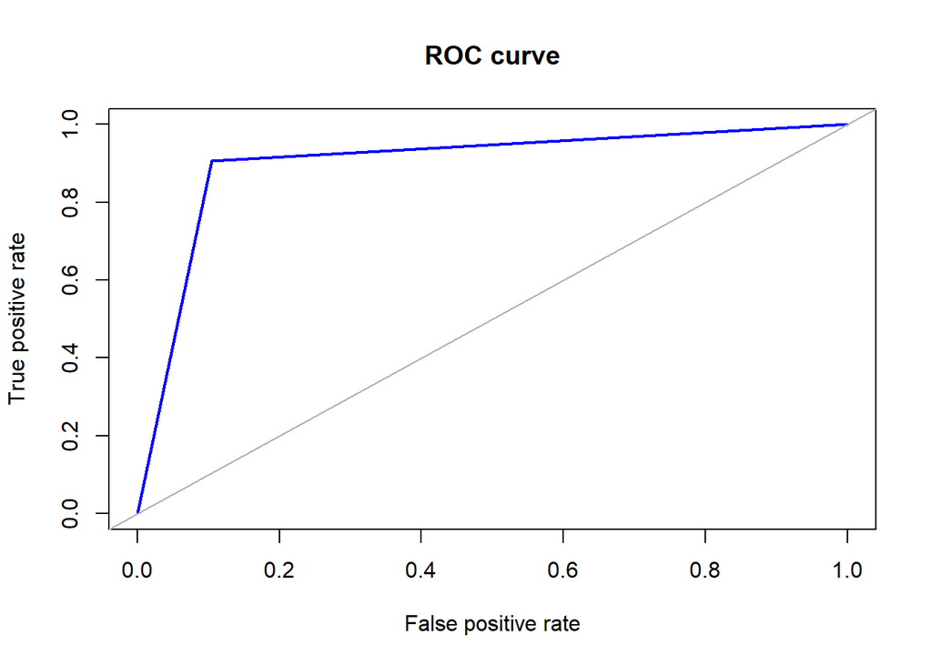

```
## Area under the curve (AUC): 0.901
```

```r
# Verificando a AUC.
roc.curve(rose_teste$is_attributed, predict_rf, plotit = T, col = "blue")
```

Vemos que conseguimos uma **acurácia** de 90% e **AUC** também 90%. Como conseguimos o desempenho esperado no início do projeto, utilizaremos o modelo rpart como definitivo.

Agora basta trazermos novos conjuntos de dados para realizarmos as predições e sabermos se um clique levará à um download ou não.